# Heatmaps

In this exercise we are going to explore different datasets and determine the appropriate color scheme for each. In the workshop, the shiny widget showed that colour changes represent sharp perceptual breaks. Therefore, you should only use a color break, if it represents something. For instance, two different data populations, positive and negative values in the data.

Lets take a look at the first dataset below.

`DatasetOne` contains average temperature data for different cities around the world.

```r
DatasetOne <- read_excel("average-monthly-temperatures-acr.xls")
DatasetOne
```

| Month | Alice Springs Aerodrome | Brisbane Airport M. O | Cairns Airport | Sydney Airport | Wagga Airport | Feuerkogel | Salzburg-Flughafen | Uccle | Belize / Phillip Goldston Intl. Airport | San Joaquin | Inukjuak, Que | Beijing | Guangzhou | Bordeaux / Merignac | Marseille / Marignane | Budapest / Lorinc | Reykjavik | Dublin Airport | Tokyo | Luxembourg / Luxembourg | Christchurch (1864-2011) | Zurich Town / Ville. | Huron Regional Airport | Colonia (1951-2011) |
| --- | --- | --- | --- | --- | --- | --- | --- | --- | --- | --- | --- | --- | --- | --- | --- | --- | --- | --- | --- | --- | --- | --- | --- | --- |
| 2008-01-01 | 32.1 | 24.4 | 27.6 | 23.1 | 25.6 | -0.3 | 1.3 | 6.5 | 24.4 | 27.2 | -23.3 | -3.0 | 12.8 | 7.8 | 9.1 | 1.2 | -0.2 | 6.4 | 5.9 | 3.6 | 17.8 | 3.1 | -10.0 | 25.0 |
| 2008-02-01 | 28.4 | 23.8 | 27.0 | 21.2 | 21.1 | -1.1 | 2.9 | 6.1 | 26.2 | 26.9 | -26.4 | 0.6 | 11.6 | 9.7 | 9.3 | 4.5 | -0.2 | 5.8 | 5.5 | 4.4 | 16.9 | 3.9 | -7.9 | 24.0 |
| 2008-03-01 | 25.9 | 22.0 | 25.6 | 21.5 | 21.6 | -3.0 | 4.8 | 6.3 | 25.9 | 26.8 | -21.4 | 9.1 | 20.1 | 9.4 | 10.7 | 6.8 | 0.8 | 6.0 | 10.7 | 4.5 | 15.1 | 4.7 | -0.6 | 21.6 |
| 2008-04-01 | 20.7 | 19.4 | 23.9 | 17.4 | 14.4 | 1.4 | 8.6 | 9.3 | 27.3 | 26.4 | -9.1 | 15.9 | 23.2 | 11.7 | 14.1 | 12.1 | 3.9 | 7.6 | 14.7 | 7.7 | 12.1 | 7.9 | 6.3 | 18.1 |
| 2008-05-01 | 15.8 | 17.1 | 22.3 | 15.4 | 11.2 | 8.3 | 15.2 | 16.4 | 28.8 | 24.8 | 1.0 | 20.3 | 25.7 | 16.7 | 18.6 | 17.4 | 8.6 | 11.6 | 18.5 | 16.1 | 7.1 | 15.4 | 12.8 | 15.2 |
| 2008-06-01 | 12.8 | 16.4 | 22.3 | 14.9 | 10.5 | 11.2 | 18.6 | 16.1 | 27.9 | 22.9 | 9.9 | 23.4 | 27.1 | 18.7 | 22.3 | 21.2 | 10.6 | 12.8 | 21.3 | 17.0 | 6.8 | 17.3 | 18.5 | 10.1 |
| 2008-07-01 | 13.0 | 14.6 | 20.7 | 12.3 | 7.9 | 11.3 | 18.5 | 18.0 | 28.2 | 26.3 | 13.8 | 27.2 | 29.2 | 20.3 | 24.4 | 21.5 | 12.5 | 14.9 | 27.0 | 18.1 | 6.5 | 18.4 | 23.1 | 13.5 |
| 2008-08-01 | 12.7 | 14.4 | 21.3 | 12.2 | 7.6 | 11.9 | 18.5 | 17.6 | 28.7 | 27.3 | 13.6 | 26.1 | 29.3 | 19.9 | 24.3 | 21.8 | 11.5 | NA | 26.8 | 17.2 | 6.0 | 17.7 | 22.4 | 12.2 |
| 2008-09-01 | 21.6 | 18.9 | 23.9 | 16.5 | 12.1 | 6.4 | 13.0 | 14.0 | 28.5 | 26.5 | 5.6 | 21.0 | 28.7 | 16.5 | 19.8 | 15.6 | 9.4 | 12.4 | 24.4 | 12.4 | 9.6 | 12.3 | 16.7 | NA |
| 2008-10-01 | 25.5 | 20.2 | 25.0 | 18.9 | 16.9 | 5.9 | 9.7 | 10.5 | 26.3 | NA | 2.4 | 14.6 | 26.1 | 13.0 | 16.0 | 12.3 | 2.8 | 8.9 | 19.4 | 9.1 | 10.8 | 10.0 | 8.8 | 16.3 |

[output cut: 26 more lines]

Lets take a look at the distribution of the data as well as the maximum and minimum temperatures to see if there are any perceptual breaks in the data.

There are a few ways to explore the dataset to see if you can notice any perceptual breaks in the data.

1. Look at the summary of the whole dataset.

```r
 summary(DatasetOne)
```

```
     Month                     Alice Springs Aerodrome Brisbane Airport M. O Cairns Airport  Sydney Airport  Wagga Airport     Feuerkogel     Salzburg-Flughafen     Uccle
 Min.   :2008-01-01 00:00:00   Min.   :11.00           Min.   :14.40         Min.   :20.70   Min.   :12.20   Min.   : 7.30   Min.   :-6.700   Min.   :-3.300     Min.   :-0.70
 1st Qu.:2008-09-23 12:00:00   1st Qu.:15.22           1st Qu.:17.18         1st Qu.:23.00   1st Qu.:15.40   1st Qu.:10.72   1st Qu.:-2.525   1st Qu.: 3.725     1st Qu.: 6.25
 Median :2009-06-16 00:00:00   Median :21.90           Median :20.50         Median :25.25   Median :18.55   Median :15.50   Median : 4.050   Median : 9.100     Median :10.55
 Mean   :2009-06-16 10:40:00   Mean   :21.32           Mean   :20.28         Mean   :24.87   Mean   :18.41   Mean   :16.12   Mean   : 3.694   Mean   : 9.361     Mean   :10.43
 3rd Qu.:2010-03-08 18:00:00   3rd Qu.:27.65           3rd Qu.:23.65         3rd Qu.:26.93   3rd Qu.:22.02   3rd Qu.:21.15   3rd Qu.: 8.975   3rd Qu.:15.700     3rd Qu.:16.18
 Max.   :2010-12-01 00:00:00   Max.   :32.10           Max.   :25.50         Max.   :28.00   Max.   :24.10   Max.   :26.50   Max.   :13.500   Max.   :20.600     Max.   :19.40

 Belize / Phillip Goldston Intl. Airport  San Joaquin    Inukjuak, Que        Beijing        Guangzhou     Bordeaux / Merignac Marseille / Marignane Budapest / Lorinc
 Min.   :22.20                           Min.   :22.90   Min.   :-26.400   Min.   :-4.80   Min.   :11.60   Min.   : 3.50       Min.   : 4.80         Min.   :-2.000
 1st Qu.:25.10                           1st Qu.:26.23   1st Qu.:-15.950   1st Qu.: 1.90   1st Qu.:18.12   1st Qu.: 8.95       1st Qu.: 9.60         1st Qu.: 5.625
 Median :27.50                           Median :27.15   Median : -3.200   Median :14.95   Median :23.60   Median :13.25       Median :15.00         Median :12.050
 Mean   :26.81                           Mean   :26.70   Mean   : -4.258   Mean   :13.06   Mean   :22.66   Mean   :13.26       Mean   :15.35         Mean   :11.492
 3rd Qu.:28.60                           3rd Qu.:27.70   3rd Qu.:  5.625   3rd Qu.:23.02   3rd Qu.:27.93   3rd Qu.:18.70       3rd Qu.:21.30         3rd Qu.:19.050
 Max.   :29.60                           Max.   :29.00   Max.   : 14.700   Max.   :28.60   Max.   :29.90   Max.   :22.10       Max.   :26.10         Max.   :23.600
 NA's   :1                               NA's   :2
   Reykjavik      Dublin Airport       Tokyo        Luxembourg / Luxembourg Christchurch (1864-2011) Zurich Town / Ville. Huron Regional Airport Colonia (1951-2011)
 Min.   :-0.200   Min.   : 0.000   Min.   : 5.500   Min.   :-2.500          Min.   : 5.200           Min.   :-1.900       Min.   :-11.400        Min.   :10.10
 1st Qu.: 1.050   1st Qu.: 5.650   1st Qu.: 9.875   1st Qu.: 4.475          1st Qu.: 7.775           1st Qu.: 4.125       1st Qu.: -1.975        1st Qu.:13.50
 Median : 4.450   Median : 8.300   Median :17.100   Median : 9.200          Median :11.500           Median : 9.800       Median :  7.800        Median :16.80
 Mean   : 5.586   Mean   : 8.891   Mean   :16.667   Mean   : 9.403          Mean   :11.592           Mean   : 9.433       Mean   :  7.033        Mean   :17.61
 3rd Qu.:10.125   3rd Qu.:12.700   3rd Qu.:23.150   3rd Qu.:16.025          3rd Qu.:15.175           3rd Qu.:15.675       3rd Qu.: 17.900        3rd Qu.:22.60
 Max.   :13.000   Max.   :16.000   Max.   :29.600   Max.   :20.500          Max.   :18.500           Max.   :20.000       Max.   : 24.100        Max.   :25.70
                  NA's   :1                                                                                                                      NA's   :3
```

2. Use visualisation to explore the distribution of the dataset.

```r
DatasetOne2 <- gather(DatasetOne, City, value, c(2:ncol(DatasetOne)))
```

- *Note: There are two different ways to do this. A histogram or Density plot. Use your preferred method here.*

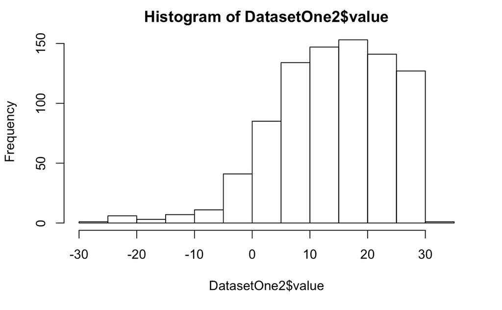

```r
hist(DatasetOne2$value)
```

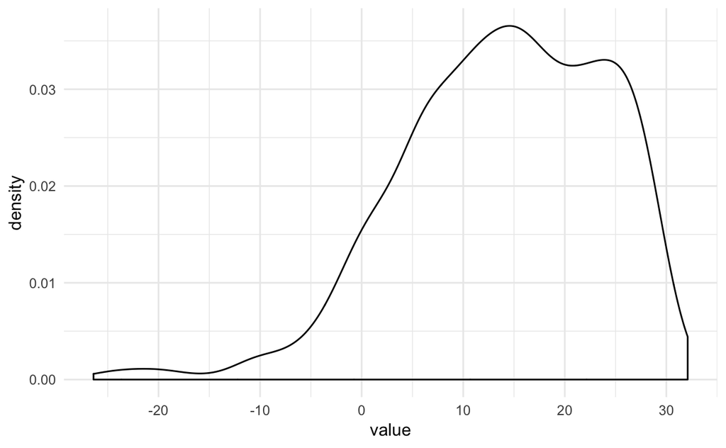

```r
ggplot(DatasetOne2, aes(x = value)) + geom_density()
```

Using the information that you have just found, determine an appropriate color scheme for this heatmap. There are three ways to change the color sheme of the heatmap.

- scale_fill_gradient() - Two-color Gradient
- scale_fill_gradient2() - Gradient with a middle color and two colors that diverge from it
- scale_fill_gradientn() - Gradient with n colors, equally spaced.

The heatmap command has been completed below, run it to take a look at the base heatmap. Then update the color scheme using one of the functions above.

Have a go at choosing your color scheme in the answer sheet notebook before scrolling down to take a look at the answer on the next page.

**Answer: Taking a look at the summary and distribution of the data we can notice on perceptual break in the data, negative and positive temperatures. With this in mind, `scale_fill_gradient2()` was used to generate a colour scheme with two different colors and a midpoint at 0.**

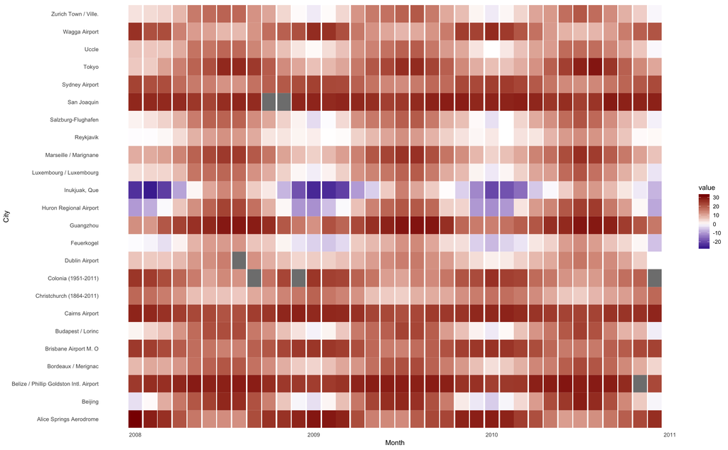

```r
DatasetOne2 <- gather(DatasetOne, City, value, c(2:ncol(DatasetOne)))
ggplot(data = DatasetOne2, aes(x = Month, y = City)) +
      geom_tile(aes(fill = value)) +
      theme(
        panel.grid.major = element_blank(),
        panel.grid.minor = element_blank(),
        panel.background = element_blank()
      ) + scale_fill_gradient2(low = "darkblue", midpoint = 0, mid = "white", high = "darkred")
```

Three more datasets have been provided in the answer sheet notebook for you to take and look at and determine the correct color scheme to use. The proposed answers to these datasets are shown on the next page. Be sure to take a go for yourself before you take a look and follow the process to explore your data before creating your heatmap.

`DatasetTwo` - contains level the highest level of education obtains for Canadians over the age of 15 by province. The data was obtained from “https://open.canada.ca/data/en/dataset/4e0ddb90-e4ad-421b-b074-ad6fb6a96dae.” `DatasetThree` - contains the crime statistics in America by state and type of crime. `DatasetFour` - contains responses from a student survey taken from “https://computerstats.wordpress.com/2016/11/26/correlation-heatmaps-r-and-excel/”. We will use this data to create a correlation matrix. The proposed color schemes are on the next page. Give the exercises a go before taking a look.

```r
DatasetThree <- read.csv("crimeRatesByState-formatted.csv", sep = ",", header = TRUE)
DatasetThree2 <- gather(DatasetThree, Type, Value, 2:ncol(DatasetThree))
```

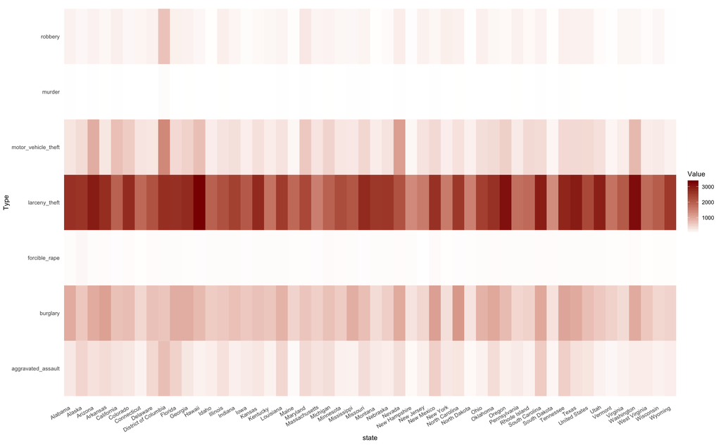

```r
ggplot(data = DatasetThree2, aes(x = state, y = Type)) +
      geom_tile(aes(fill = Value)) +
      theme(
        panel.grid.major = element_blank(),
        panel.grid.minor = element_blank(),
        panel.background = element_blank(),
        axis.text.x = element_text(angle = 30, hjust = 1)
        ) + scale_fill_gradient2(low = "white", high = "darkred")
```

```r
DatasetTwo <- read_excel("canadaeducation2.xls")
DatasetTwo
```

| Geographic_name_province_or_territory | No certificate, diploma or degree (% distribution 2016) | Secondary (high) school diploma or equivalency certificate (% distribution 2016) | Apprenticeship or trades certificate or diploma (% distribution 2016) | College, CEGEP or other non-university certificate or diploma (% distribution 2016) | University certificate or diploma below bachelor level (% distribution 2016) | University certificate, diploma or degree at bachelor level or above (% distribution 2016) |
| --- | --- | --- | --- | --- | --- | --- |
| Newfoundland and Labrador | 22.9 | 22.7 | 14.3 | 25.5 | 1.7 | 12.8 |
| Newfoundland and Labrador | 23.1 | 20.9 | 22.0 | 21.8 | 1.5 | 11.0 |
| Newfoundland and Labrador | 23.0 | 24.3 | 7.9 | 28.7 | 1.9 | 14.4 |
| Newfoundland and Labrador | 13.3 | 20.0 | 17.7 | 31.5 | 2.1 | 15.3 |
| Newfoundland and Labrador | 14.5 | 18.5 | 26.6 | 25.3 | 2.4 | 12.1 |
| Newfoundland and Labrador | 12.2 | 21.3 | 9.7 | 37.1 | 1.8 | 18.2 |
| Newfoundland and Labrador | 4.3 | 22.6 | 14.0 | 36.6 | 2.2 | 18.3 |
| Newfoundland and Labrador | 5.4 | 24.3 | 27.0 | 35.1 | 5.4 | 8.1 |
| Newfoundland and Labrador | 3.6 | 21.4 | 7.1 | 41.1 | 3.6 | 25.0 |
| Newfoundland and Labrador | 9.7 | 16.7 | 14.5 | 36.6 | 3.2 | 19.4 |

[output cut: 990 more lines]

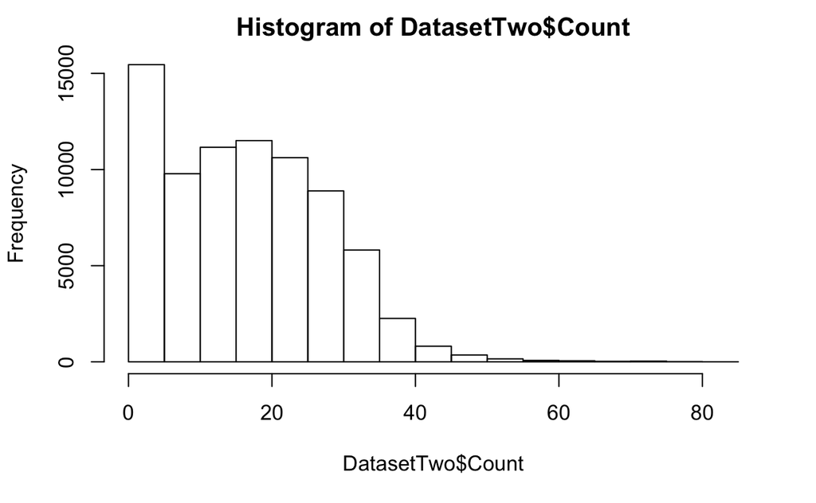

```r
DatasetTwo <- gather(DatasetTwo, Type, Count, 2:ncol(DatasetTwo))
hist(DatasetTwo$Count)
```

```r
DatasetTwo
```

| Geographic_name_province_or_territory | Type | Count |
| --- | --- | --- |
| Newfoundland and Labrador | No certificate, diploma or degree (% distribution 2016) | 22.9 |
| Newfoundland and Labrador | No certificate, diploma or degree (% distribution 2016) | 23.1 |
| Newfoundland and Labrador | No certificate, diploma or degree (% distribution 2016) | 23.0 |
| Newfoundland and Labrador | No certificate, diploma or degree (% distribution 2016) | 13.3 |
| Newfoundland and Labrador | No certificate, diploma or degree (% distribution 2016) | 14.5 |
| Newfoundland and Labrador | No certificate, diploma or degree (% distribution 2016) | 12.2 |
| Newfoundland and Labrador | No certificate, diploma or degree (% distribution 2016) | 4.3 |
| Newfoundland and Labrador | No certificate, diploma or degree (% distribution 2016) | 5.4 |
| Newfoundland and Labrador | No certificate, diploma or degree (% distribution 2016) | 3.6 |
| Newfoundland and Labrador | No certificate, diploma or degree (% distribution 2016) | 9.7 |

[output cut: 990 more lines]

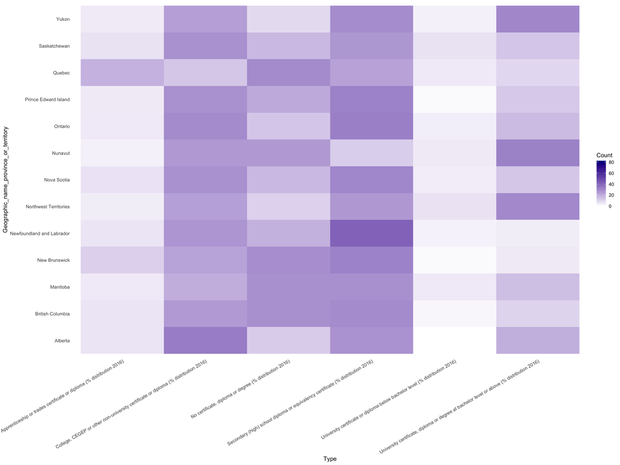

```r
ggplot(data = DatasetTwo, aes(x = Type, y = Geographic_name_province_or_territory)) +
      geom_tile(aes(fill = Count)) +
      theme(
        panel.grid.major = element_blank(),
        panel.grid.minor = element_blank(),
        panel.background = element_blank(),
        axis.text.x = element_text(angle = 30, hjust = 1)
        ) + scale_fill_gradient2(low = "white", high = "darkblue")
```

```r
original <- read.csv("StudentSurvey.csv", header = TRUE)
original1 <- original[,6:ncol(original)]
DatasetFour <- cor(original1, use="na.or.complete")
DatasetFour <- melt(DatasetFour)
DatasetFour
```

| Var1 | Var2 | value |
| --- | --- | --- |
| Exercise | Exercise | 1.000000000 |
| TV | Exercise | 0.029452188 |
| Height | Exercise | 0.119938548 |
| Weight | Exercise | 0.130634680 |
| Siblings | Exercise | -0.038946319 |
| BirthOrder | Exercise | 0.002625534 |
| VerbalSAT | Exercise | -0.050164457 |
| MathSAT | Exercise | -0.006211790 |
| SAT | Exercise | -0.033999481 |
| GPA | Exercise | -0.158551679 |

[output cut: 134 more lines]

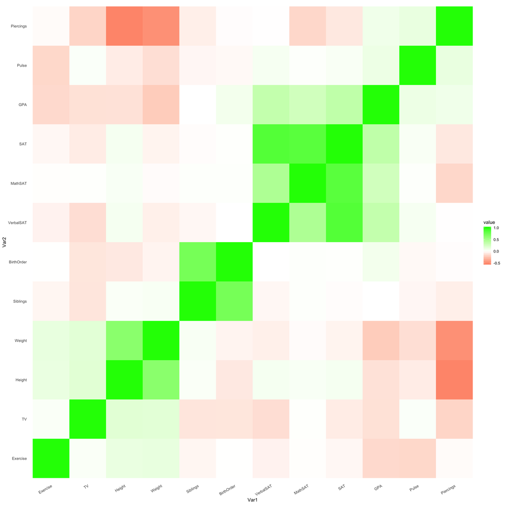

```r
ggplot(data = DatasetFour, aes(x = Var1, y = Var2)) +
      geom_tile(aes(fill = value)) +
      theme(
        panel.grid.major = element_blank(),
        panel.grid.minor = element_blank(),
        panel.background = element_blank(),
        axis.text.x = element_text(angle = 30, hjust = 1)
        ) + scale_fill_gradient2(low = "red", high = "green")
```